# Введение в Linux

Отчёт по третьему этапу прохождения внешнего курса

Кулаженкова Яна Сергеевна

1032253497@rudn.ru

Российский университет дружбы народов

2026-05-16

# Информация

## Докладчик

- Кулаженкова Яна Сергеевна
- Студентка группы НКАбд-03-25
- Российский университет дружбы народов им. Патриса Лумумбы
- 1032253497@rudn.ru

# Вводная часть

## Актуальность

- Редактор vim и bash-скрипты — основа автоматизации в Linux
- Продвинутый поиск (find, grep, sed) ускоряет работу с файлами
- Gnuplot позволяет визуализировать данные
- Управление правами и дисковым пространством — важные навыки администрирования

## Объект и предмет исследования

- **Объект:** продвинутые инструменты командной строки Linux
- **Предмет:** навыки эффективной работы с:
  - текстовым редактором vim
  - bash-скриптами (переменные, циклы, ветвления)
  - поиском (find, grep, sed)
  - визуализацией (gnuplot)
  - системными утилитами (chmod, wc, du)

## Цели и задачи

**Цель:** освоение продвинутых навыков работы в Linux.

**Задачи:** 1. Изучить основные команды редактора vim 2. Научиться писать bash-скрипты (переменные, циклы, условия) 3. Освоить продвинутый поиск файлов и текста 4. Приобрести навыки построения графиков в gnuplot 5. Изучить системные утилиты для управления файлами

# Выполнение заданий курса

## 3.1 Текстовый редактор vim — выход

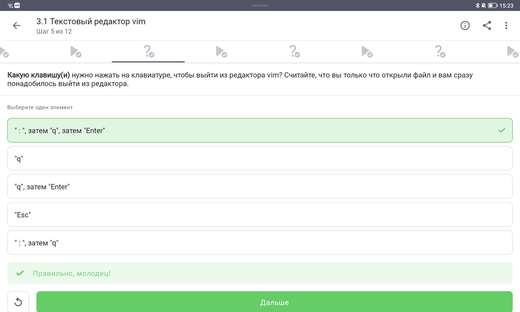

**Вопрос:** Как выйти из vim сразу после открытия файла?

**Правильный ответ:** `:`, затем `q`, затем `Enter`

## vim — режимы работы

| Режим | Назначение |
| --- | --- |
| Нормальный | Навигация, удаление, копирование |
| Вставки | Ввод текста |
| Командный | Выполнение команд (`:q`, `:w`, `:%s`) |

- Для выхода: `:` → `q` → `Enter`

## 3.1 vim — навигация (w vs W)

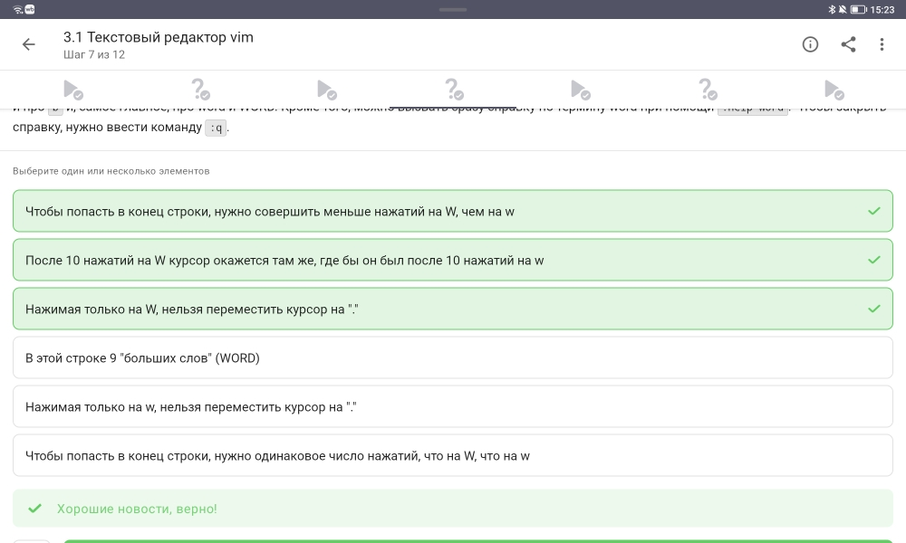

**Вопрос:** Верные утверждения о `w` и `W`

## vim — навигация по словам

| Клавиша | Тип | Разделители |
| --- | --- | --- |
| `w` | слово (word) | буквы, цифры, `_` |
| `W` | БОЛЬШОЕ СЛОВО (WORD) | только пробелы |

- Знаки препинания (`.`, `,`) — разделители для `w`, но не для `W`

## 3.1 vim — редактирование строки

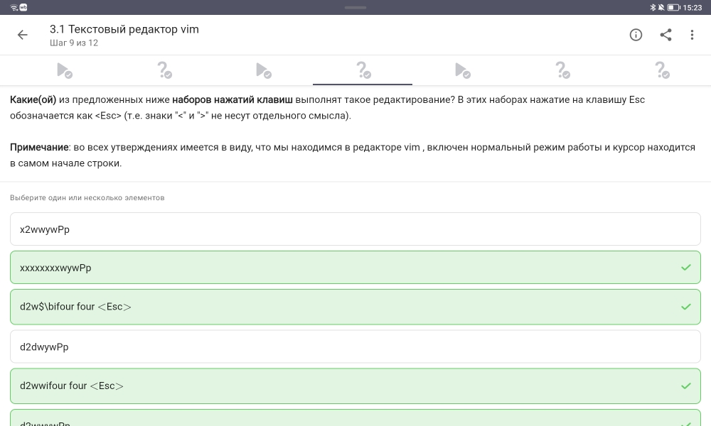

**Задание:** Выбрать наборы клавиш для редактирования

## vim — команды редактирования

| Команда | Действие |
| --- | --- |
| `d` | удалить |
| `y` | скопировать (yank) |
| `p` | вставить после курсора |
| `P` | вставить перед курсором |
| `w` | перемещение по словам |
| `$` | в конец строки |
| `i` | режим вставки |

## 3.1 vim — замена текста

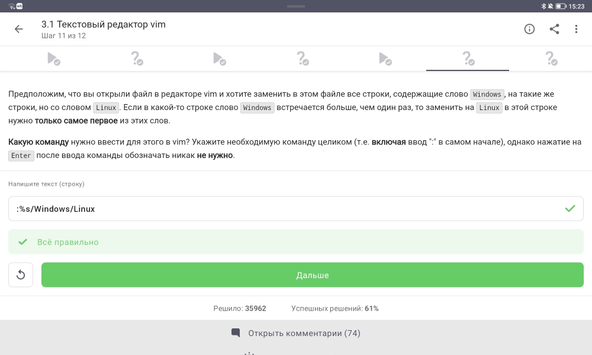

**Задание:** Замена `Windows` → `Linux` (первое вхождение в строке)

**Правильный ответ:** `:%s/Windows/Linux`

## vim — команда substitute

```
# Первое вхождение в строке (по умолчанию)
:%s/Windows/Linux

# Все вхождения в строке
:%s/Windows/Linux/g

# С подтверждением
:%s/Windows/Linux/gc
```

- `%` — весь файл
- `s` — substitute

## 3.2 Bash — история команд

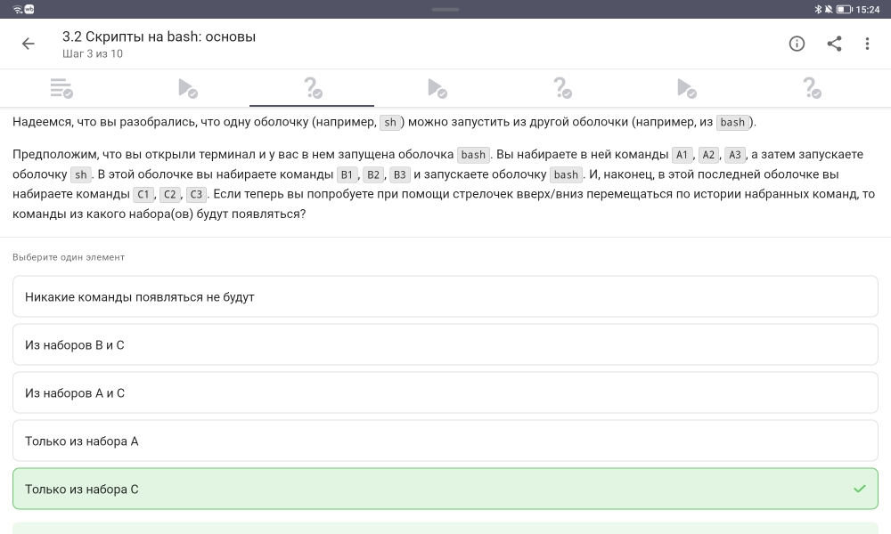

**Вопрос:** Какие команды будут в истории после вложенных оболочек?

**Правильный ответ:** Только из набора C

## Bash — история команд

```bash
bash          # A1, A2, A3
    sh        # B1, B2, B3
        bash  # C1, C2, C3  ← текущая оболочка
```

- Каждая оболочка имеет **свою историю**
- История не наследуется

## 3.2 Bash — абсолютный путь

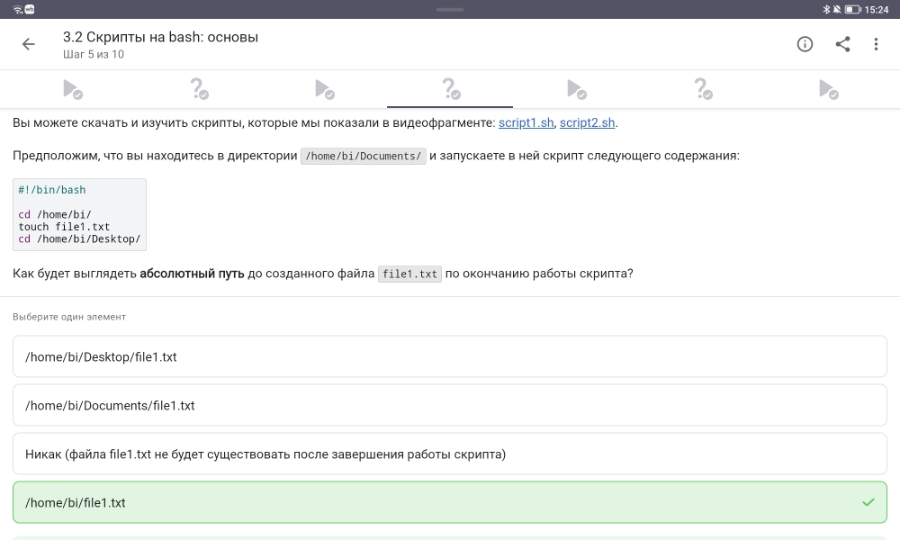

**Вопрос:** Где будет создан `file1.txt`?

**Правильный ответ:** `/home/bi/file1.txt`

## Bash — влияние cd

```bash
#!/bin/bash
cd /home/bi/           # переход в /home/bi
touch file1.txt        # файл создаётся в /home/bi/
cd /home/bi/Desktop/   # переход (не влияет на файл)
```

- Файл остаётся там, где был создан